# An Implementation of Narcissism in R

2017-02-26

This post is more an *example* of narcissism, but *implementation* has a nice technical ring to it.

*Narcissism* hasn’t been a word in my every-day vocabulary, although it has been in the news with greater frequency lately. We have seen a lot of discussions recently about [narcissistic personality disorder](https://www.theatlantic.com/magazine/archive/2016/06/the-mind-of-donald-trump/480771/), but that is not what I am talking about here. At least I hope not, because I’m talking about me.

Here’s the definition that fits this post:  
[Narcissism](http://www.dictionary.com/browse/narcissism) noun  
1. inordinate fascination with oneself; excessive self-love; vanity. Synonyms: self-centeredness, smugness, egocentrism.

So “inordinate fascination with oneself” may be a good characterization of the datasets presented here. I don’t think “excessive self-love” or “vanity” have much to do with it.

### A Twenty Year History of My Weight

For the last twenty-one years I have been recording my weight almost every single morning. I try to follow a consistent protocol. I’m in my pajamas before I go downstairs for tea and breakfast. It’s a more stable and reliable measure of weight than what is recorded in my doctor’s office. I have owned three scales during the twenty-one year period. The first one was analog and I wrote down my weight to the nearest pound. When I got a dgital scale in 2004, I used both scales for a period of time and adjusted the measurements from the analog scale according to the average difference from the digital scale. In short, I was serious about trying to establish a reliable measurement over time.

Is it weird or creepy to publish this data series on the internet? I’ll say some more about that at the bottom of the post. For now, bring on the data.

The R code used to plot this weight history isn’t terribly interesting, but I’ll show my work anyway. First I am showing the weight by day.

```r
suppressPackageStartupMessages(
  library(tidyverse))
# tidyverse loads these packages:
# Loading tidyverse: ggplot2
# Loading tidyverse: tibble
# Loading tidyverse: tidyr
# Loading tidyverse: readr
# Loading tidyverse: purrr
# Loading tidyverse: dplyr
suppressPackageStartupMessages(library(stringr))    # for processing strings
suppressPackageStartupMessages(library(lubridate))  # for dates
```

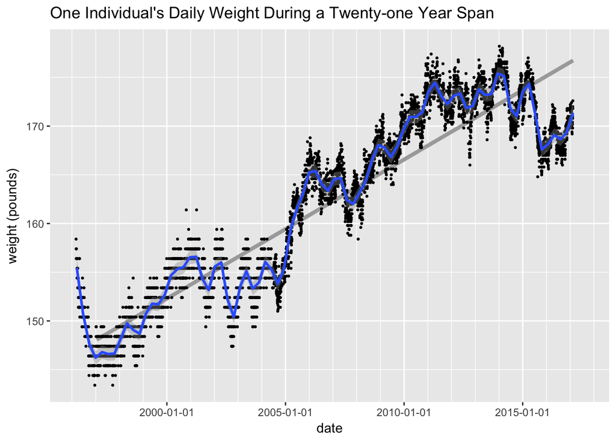

```r
weight_data<-read_csv(file.path("/Users", "john_imac", "Dropbox", "Programming","R_Stuff", "John Vitals","john weight.csv"), col_types = cols(
     date = col_date("%m/%d/%Y")))

weight_data$month <- month(weight_data$date, label = TRUE)
weight_data$weight <- ifelse(is.na(weight_data$adjusted), weight_data$raw, weight_data$adjusted)
# in 2004 I started entering data without decimals to save time, so 1746 is 174.6
# Next line converts the numbers that are so large they must be four digits without decimal:
weight_data$weight <- ifelse(weight_data$weight > 250, weight_data$weight / 10, weight_data$weight)
weight_data$year <- factor(year(weight_data$date)) # I'll use this for the second chart

# get average weight by month
weight_data$mid_month <- floor_date(weight_data$date, unit = "month") + days(14)
wtm <- group_by(weight_data, mid_month, month) %>% summarise(weight = mean(weight, na.rm = TRUE))
wtm2 <- filter(wtm, year(mid_month) > 1996) # weight by month, but without partial 1996
byday <- ggplot(data = weight_data, aes(x = date, y = weight)) + scale_x_date(date_breaks = "5 years", date_minor_breaks = "1 year")
#  put the gray regression line first so that it is underneath the points and the other loess smoothed line.
byday <- byday + geom_smooth(method = "lm", se = FALSE, data = wtm2, aes(x = mid_month), colour = "darkgray", size = 1.5)
byday <- byday + geom_point(size = 0.5) +  geom_smooth(data = wtm, aes(x = mid_month), span = 0.07)
byday <- byday + ggtitle("One Individual's Daily Weight During a Twenty-one Year Span") + ylab("weight (pounds)")
```

### Weight Gain by Year

For a somewhat glib discussion of weight gain by year, see Wonkblog [Look at how much weight you are going to gain](https://www.washingtonpost.com/news/wonk/wp/2016/01/29/the-age-when-you-gain-the-most-weight/?utm_term=.082bca258fcb). The article says the expected gain is between 0.5 and 1.5 pounds per year. The straight dark gray line on my weight chart is the regressioin line through the monthly data, but without the bit at the left end in 1996. The slope is about 1.4 pounds per year.

#### National Statistics on Weight by Age

What do we know about weight by age in the general population? One source is the [National Health and Nutrition Examination Survey](https://wwwn.cdc.gov/nchs/nhanes/ContinuousNhanes/Questionnaires.aspx?BeginYear=2015) or **NHANES**. (There is a summary report for [Anthropometric Reference Data](https://www.cdc.gov/nchs/data/series/sr_03/sr03_039.pdf) that includes weight.) That is the source for the Wonkblog referred to above. It also seems to be the source for these charts (for white women and men) which were compiled at [Dr. Halls](http://halls.md/average-height-weight-charts/) website, which does not exactly reek of credibility.

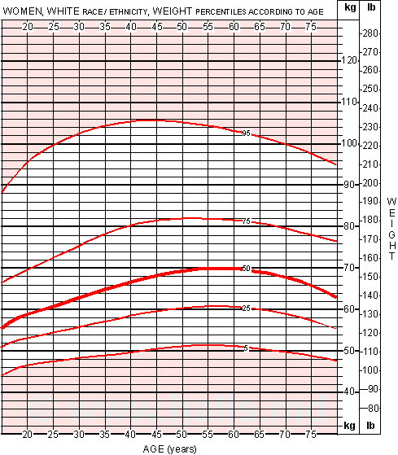

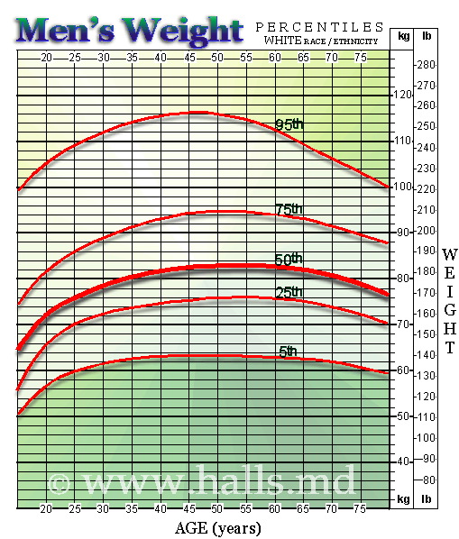

The CDC NHANES survey seems to be done annually so it would be possible to look at the change in the distribution over time. They have data sets for the [National Health and Nutrition Examination Survey](https://wwwn.cdc.gov/nchs/nhanes/Search/DataPage.aspx?Component=Examination) year by year from 1999 to 2013.

I confess I’m not sufficiently interested in the issue of weight and age to dig in and try to get all that sorted out. Maybe I’ll come back to this. Were I to get interested, there is quite a bit of raw data available from NHANES for download as XPT files, which I see is the SAS data transport format. As usual, [Hadley](https://github.com/hadley) is one step ahead of me and the latest version of [haven 1.0.0.9](https://github.com/tidyverse/haven/blob/master/NEWS.md) (which is not yet up on [CRAN](https://cran.r-project.org/)) adds `read_xpt` as a command to read XPT SAS transport datasets. Maybe I’ll try that at some point, but in the meantime I want to press ahead with my more self-centered (or should I say *narcissistic*) exploraton of my personal body statistics.